# Syntyvyyskehityksen ennustaminen

Antti J. Tanskanen, Elinkeinoelämän keskusliitto EK

20.9.2018

## Johdanto

Syntyneiden määrällä on viiveellä vaikutusta työikäisen väestön määrään, ja sitä kautta syntyvyyden laskulla on vaikutuksia mm. sosiaaliturvan rahoituksen kestävyyteen. Eläketurvakeskuksen laskelmien mukaan syntyvyyden lasku aiheuttaa työeläkemaksussa pitkällä aikavälillä useiden prosenttiyksiköiden nousupaineen (Tikanmäki, 2017). Myös Väestöntutkimuslaitos on analysoinut syitä syntyvyyden laskulle, mutta selkeätä syytä ei ole löytynyt (Rotkirch et al, 2017)

Tässä tutkimuksessa jatketaan aiemman harjoituksen mallilla ja kokeillaan miten hyvin ennuste toimii.

## Aineisto

Tutkimuksessa käytetty aikasarja-aineisto on peräisin tilastokeskuksen StatFin-tietokannasta, ETK:lta ja Human Mortality Databasesta. Aineisto koostuu vuosien 1989-2017 datasta. Väestörakenteesta (Tilastokeskus) mukana on syntyneidet lukumäärät, kokonaishedelmällisyysluvut, synnyttäjien keski-ikä ja naisten lukumäärät 5-vuotisikäryhmittäin. Mukana ovat myös avioliittojen määrät 10-vuotisikäluokittain suhteutettuna ikäluokkien suuruuteen (Tilastokeskus).

Työllisyyttä (Tilastokeskus) kuvataan 10-vuotisikäluokittaisilla työllisyysasteilla sukupuolittain, 10-vuotisikäluokkakohtaisista työttömyysasteista sukupuolittain (suhteutettu ikäluokan kokoon, ), ja työsuhteiden tyyppitiedoilla (jatkuva/määräaikainen; kokoaikainen/osa-aikainen) vuosilta 1997-2017. Pienituloisuutta kuvaa 10-vuotisikäluokittainen pienituloisten osuus (tulos alle 60 % mediaanitulosta) väestöstä (Tilastokeskus). Kaupungistumista kuvaa maalla, ulommassa kaupungissa ja sisemmässä kaupungissa asuvien osuudet väestöstä (Tilastokeskus) Eläkejärjestelmän vaikutusta syntyvyyteen yritetään selvittää käyttämällä vertailukohtana eläkemenoa BKT:stä (Eläketurvakeskus). Lapsikuolleisuus (Human mortality database).

Kaikkiaan lähtöaineistossa on 39 aikasarjaa, joissa on 29 havaintoa vuosilta 1989-2017, tosin osasta aikasarjoja vuosien 1989 ja/tai 2017 luvut puuttuvat. Pidempiä aikasarjoja löytyy syntyneistä, naisten 5-vuotisikäluokittaisesta määrästä ja hedelmällisyysluvusta. Näistä käytetään aikasarjoja vuosilta 1970-2017.

Aineiston perusteella ei voi tehdä kausaalisia päätelmiä, ainostaan assosiatiivisuutta koskevia. Tämä tietenkin rajoittaa tulkintamahdollisuuksia.

Tarkoituksena on avoimen, toistettavan tutkimuksen hengessä näyttää täsmällisesti mitä on tehty. Tästä syystä alkuperäinen aineisto (myös tämä työkirja koodeineen, Rmd-muotoisena; data Rdata-muodossa) on kokonaisuudessaan saatavissa osoitteesta https://github.com/ajtanskanen/Syntyvyyden-tekij-t

# Hedelmällisyysluvun muutoksia selittävä malli

Synnytysikäisten naisten lukumäärää pystytään lyhyellä aikavälillä ennustamaan melko hyvin, eikä siihen vaikuta juurikaan muut tekijät, kuten vaikkapa työllisyys tai taloudellinen tilanne. Jos sellaiset tekijät vaikuttavat syntyvyyteen, vaikutuksen pitäisi näkyä hedelmällisyysluvussa.

Yritetään sitten selittää hedelmällisyysluvun muutoksia käyttäen faktoreina kokoelmaa erilaisia tekijöitä ikäluokka- ja sukupuolikohtaisia avioituvuuksia ja pienituloisuusosuusasteita (60% mediaanitulosta); synnyttäjien keski-ikää, alle 1-vuotiaiden kuolleisuutta, eläkemenon bkt-osuutta, sekä sisäkaupungissa, ulkokaupungissa ja maaseudulla asuvien osuutta väestöstä.

```r
syntyvyys_reg = bas.lm(hedelmallisyysluku ~pienituloisuus_18_24 + pienituloisuus_25_34 + lapsikuolleisuus + synnyttajien_keskiika + avioituvuus_naiset_25_29_lag1 + avioituvuus_naiset_30_34_lag1 + elakemeno + kehyskaupunki + sisempikaupunki + ulompikaupunki + maaseudulla, data = syntyvyysaineisto_redusoitu,
prior = "ZS-null", modelprior = uniform())
```

```
##                               P(B != 0 | Y) model 1 model 2 model 3
## Intercept                             1.000   1.000   1.000   1.000
## pienituloisuus_18_24                  0.178   0.000   0.000   0.000
## pienituloisuus_25_34                  0.151   0.000   0.000   0.000
## lapsikuolleisuus                      0.207   0.000   0.000   0.000
## synnyttajien_keskiika                 0.470   1.000   0.000   1.000
## avioituvuus_naiset_25_29_lag1         0.585   1.000   1.000   0.000
## avioituvuus_naiset_30_34_lag1         0.527   0.000   0.000   1.000
## elakemeno                             0.174   0.000   0.000   0.000
## kehyskaupunki                         0.273   0.000   0.000   0.000
## sisempikaupunki                       0.743   1.000   1.000   1.000
## ulompikaupunki                        0.797   1.000   1.000   1.000
## maaseudulla                           0.334   0.000   0.000   0.000
## BF                                       NA   1.000   0.910   0.506
## PostProbs                                NA   0.066   0.060   0.034
## R2                                       NA   0.937   0.923   0.933
## dim                                      NA   5.000   4.000   5.000
## logmarg                                  NA  23.622  23.527  22.941
```

Todennäköisyyspainotetut regressiokertoimet ovat

```
##
##  Marginal Posterior Summaries of Coefficients:
##
##  Using  BMA
##
##  Based on the top  2048 models
##                                post mean   post SD     post p(B != 0)
## Intercept                       1.7762963   0.0040163   1.0000000
## pienituloisuus_18_24            0.0003558   0.0013469   0.1783202
## pienituloisuus_25_34           -0.0001492   0.0027172   0.1508065
## lapsikuolleisuus                3.6639660  11.6278927   0.2067503
## synnyttajien_keskiika          -0.0617511   0.0821654   0.4699072
## avioituvuus_naiset_25_29_lag1   0.0031142   0.0031100   0.5851563
## avioituvuus_naiset_30_34_lag1   0.0028056   0.0031640   0.5273680
## elakemeno                       0.0001168   0.0031081   0.1741093
## kehyskaupunki                   0.0170772   0.0690266   0.2734722
## sisempikaupunki                -0.0652613   0.0522549   0.7427097
## ulompikaupunki                  0.1021449   0.0673821   0.7970592
## maaseudulla                     0.0103477   0.0437532   0.3335604
```

Aggregaattikertoimet kaikissa mallissa todennäköisyyksillä painotettuna ovat

```
##
##  Marginal Posterior Summaries of Coefficients:
##
##  Using  BMA
##
##  Based on the top  2048 models
##                                post mean   post SD     post p(B != 0)
## Intercept                       1.7762963   0.0040163   1.0000000
## pienituloisuus_18_24            0.0003558   0.0013469   0.1783202
## pienituloisuus_25_34           -0.0001492   0.0027172   0.1508065
## lapsikuolleisuus                3.6639660  11.6278927   0.2067503
## synnyttajien_keskiika          -0.0617511   0.0821654   0.4699072
## avioituvuus_naiset_25_29_lag1   0.0031142   0.0031100   0.5851563
## avioituvuus_naiset_30_34_lag1   0.0028056   0.0031640   0.5273680
## elakemeno                       0.0001168   0.0031081   0.1741093
## kehyskaupunki                   0.0170772   0.0690266   0.2734722
## sisempikaupunki                -0.0652613   0.0522549   0.7427097
## ulompikaupunki                  0.1021449   0.0673821   0.7970592
## maaseudulla                     0.0103477   0.0437532   0.3335604
```

Tarkastetaan vielä, millaisia residuaaleja jää selittämättä mallilla

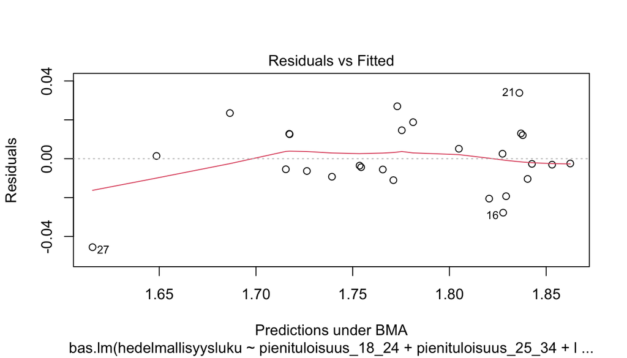

Ja lopuksi verrataan mallin sovitetta

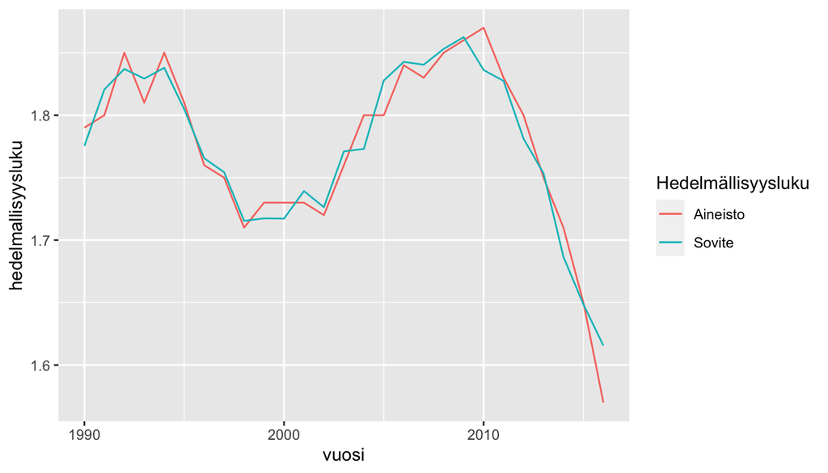

# Ennuste

Pyritään sitten arvioimaan miten hedelmällisyysluku kehittyy, mikäli 10 viime vuoden trendi jatkuisi näiden neljän tekijän osalta. Jatketaan trendiä lineaarisesti avioituvuudelle, kaupungistumiselle ja synnyttäjien keski-iälle. Muut tekijät pidetään vakiona.

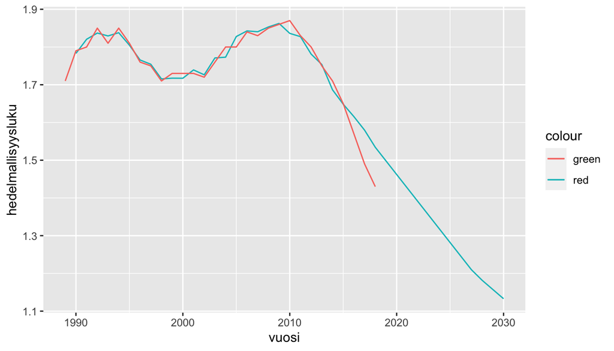

Meillä on nyt ennuste hedelmällisyysluvusta, joten käytetään sitä ja väestöennusteen naisten lukumääriä arvioimaan lasten määriä

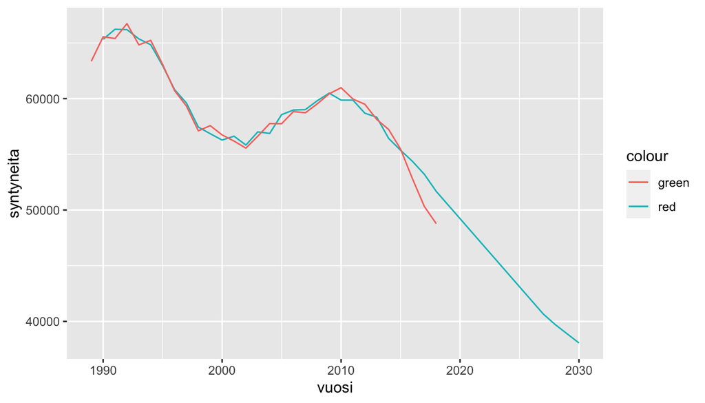

## Syntyvyyden laskun syyt

Vaikka tällä tutkimuksella ei pääse kiinni syntyvyyden laskun kausaalisiin syihin, näkyy tuloksista selvästi, että syntyvyyden laskua ajaa kaksi erilaista tekijää: hedelmällisyysluvun lasku ja synnytysikäisten naisten lukumäärän lasku. Vaikeampaa on yrittää selittää, mistä hedelmällisyysluvun lasku johtuu.

Tilastokeskuksen tiedoista tiedetään, että kaupungeissa syntyvyys on alempaa kuin muussa maassa: “Vastaavasti matalin syntyvyys oli jaksolla 2013–2017 Helsingissä, jossa kokonaishedelmällisyysluku oli 1,27. Turussa luku oli 1,29 ja Tampereella 1,34. Myös kaikkien kuntien vertailussa viimeksi mainittujen kaupunkien syntyvyys oli matalimpien joukossa.” (Tilastokeskus, väestörakenne 2018).

Regressiokerrointen mukaan sisemmässä kaupungissa asuvien osuuden kasvu alentaa syntyvyyttä ja lykkää lasten hankintaa. Toisaalta ulommassa kaupungissa (samoin kuin maaseudulla) asuvien osuuden kasvu näyttäisi lisäävän syntyvyyttä ja vähentävän lastenhankinnan lykkäämistä. Tulokset ovat intuition mukaisia, koska sisemmissä kaupungeissa erityisesti lapsiperheille sopivien asuntojen hintataso on korkea, kun taas kauempana kaupunkien keskustoista hintataso on alempi. Kaupungistuminen ei siis välttämättä alenna syntyvyyttä, vaikka sisäkaupungeissa asuvien osuuden kasvu näyttää alentavan syntyvyyttä.

Tässä tutkimuksessa aineisto koostui pienestä määrästä havaintoja. Tästä syystä tuloksiin on syytä suhtautua varovaisuudella, vaikka usealle löydetylle tekijälle on selkeä selitys. Pyrittäessä soveltamaan faktorimallia eteenpäin, näkyy selvästi että hedelmällisyysluku laskee jyrkemmin kuin malli ennakoi. Tässä tutkimuksessa ei päästy kiinni eron syihin, joten joko faktoreita puuttuu mallista tai faktoripainot ovat siinä vääriä. Joka tapauksessa näyttää, että syntyvyyteen vaikuttavat tekijät ovat muita kuin aiemmin.

## Johtopäätökset

Ennustemalli arvioi aivan oikein syntyvyyskehityksen alenevan, mutta alenemisnopeus on toteutuneeseen verrattuna liian pieni. Tämä kertoo joko faktoripainojen muuttuneen viime vuosina, tai todennäköisemmin siitä että mukaan on tullut muutosnopeuteen vaikuttavia tekijöitä, joita ei tässä tutkimuksessa ole huomioitu.

# Viittaukset

Becker, G.S., Barro, R.J., Reformulation of the economic theory of fertility, The quarterly journal of economics, 1988

Boldrin, M., De Nardi, M., Jones, L.E. Fertility and social security, Journal of Demographic Economics 81, 261-299, https://doi.org/10.1017/dem.2014.14, 2015

Doepke, M., Child mortality and fertility decline: Does the Barro-Becker model fit the facts?

Hiilamo, H. T., Fertility Response to Economic Recessions in Finland 1991–2015 Finnish Yearbook of Population Research 52, 15-28 . DOI: 10.23979/fypr.65254, 2017

Kohler, H.-P., Kohler, I., Fertility Decline in Russia in the Early and Mid 1990s: The Role of Economic Uncertainty and Labour Market Crises, European Journal of Population 18, 233-262, https://doi.org/10.1023/A:1019701812709, 2002.

Martine, G., Alves, J.E., Cavenaghi, S., Urbanization and fertility decline: Cashing in on structural change, IIED Working paper, 2013

Miettinen, A., Miksi syntyvyys laskee? Suomalaisten lastensaantiin liittyviä toiveita ja odotuksia. Perhebarometri 2015. Väestöliitto, 2015.

Miettinen, A., Jalovaara, M. Stable employment – more babies? Life stage and educational differences in the effects of labour market attachment on first birth among Finnish men and women. Working Papers on Social and Economic Issues 15/2016, Turku Center for Welfare Research, 2016

Rotkirch, A., Tammisalo, K., Miettinen, A., Berg, V. Miksi vanhemmuutta lykätään? Perhebarometri, 2017.

Tikanmäki, H., Huomisen aikuiset syntyvät nyt, Eläketurvakeskuksen blogi https://www.etk.fi/blogit/huomisen-aikuiset-syntyvat-nyt/, 2017

# Liite: Aika-sarjojen kuvaukset

*syntyneet* Syntyneiden lasten lukumäärä. Lähde: Tilastokeskus

*hedelmallisyysluku* “Kokonaishedelmällisyysluku saadaan laskemalla yhteen yhdelle ikävuodelle lasketut hedelmällisyysluvut. Näin saatu luku tarkoittaa laskennallista lasten määrää, jonka nainen synnyttää kyseisen vuoden hedelmällisyyden pysyessä voimassa naisen koko hedelmällisen kauden edellyttäen, ettei hän kuole ennen tämän kauden päättymistä.” Lähde: Tilastokeskus, Väestörakenne-tilasto

*pienituloisuus_0_17, pienituloisuus_18_24, pienituloisuus_25_34, pienituloisuus_35_49, pienituloisuus_50_64* “Pienituloisuusaste: Pienituloisten osuus kyseisessä väestöryhmässä. Pienituloisia henkilöitä: Pienituloisia henkilöitä kyseisessä väestöryhmässä. Pienituloisten mediaanitulo: Pienituloisten ekvivalentit mediaanitulot kyseisessä väestöryhmässä. Köyhyysvaje: Pienituloisten tulomediaanin ja koko väestön pienituloisuusrajan erotus prosentteina rajasta. Ekvivalenttitulo: Kotitalouden käytettävissä olevat rahatulot kulutusyksikköä kohden vuodessa. Kulutusyksikkö: Modifioitu OECD-asteikko (1.0 - 0.5 - 0.3). Pienituloisuusrajat lasketaan vuosittain kaikkien kotitalouksien ekvivalenttitulon mediaanin perusteella. Julkaisuissa käytetty virallinen pienituloisuusraja on 60 % mediaanitulosta ja tulokäsite käytettävissä olevat rahatulot.Euromääräiset tiedot on esitetty vuoden 2016 rahassa.” Lähde: Tilastokeskus, Tulonjakotilasto

*lapsikuolleisuus* Alle 1-vuotiaana kuolleiden osuus elävänä syntyneistä. Lähde: Human mortality database

*tyollisyysaste_miehet_15_24_lag1, tyollisyysaste_naiset_25_34_lag1, tyollisyysaste_miehet_35_44_lag1, tyollisyysaste_naiset_15_24_lag1, tyollisyysaste_miehet_25_34_lag1, tyollisyysaste_naiset_45_44_lag1* Yhden vuoden viivästetty 10-vuotisikäluokittainen työllisyysaste miehille ja naisille. Lähde: Tilastokeskus

*synnyttajien_keskiika* Laskettu synnyttäneiden äitien ikien keskiarvona. Lähde: Tilastokeskus

*avioituvuus_naiset_25_29, avioituvuus_naiset_30_34* Naisten solmittujen avioliittojen lukumäärä suhteessa samanikäisten naisten lukumäärään. Lähde: Tilastokeskus

*elakemeno* Kokonaiseläkemeno Suomessa prosentteina BKT:stä Lähde: Eläketurvakeskus

*kaupungissaasuvat, maaseudulla, sisakaupungissa* Kaupungeissaasuvien osuus väestöstä, maaseudulla asuvien osuus väestöstä ja Lähde: Tilastokeskus

*jatkuvakokoaika_miehet, jatkuvaosaaika_miehet, maaraaikakoko_miehet, maaraaikaosa_miehet, jatkuvakokoaika_naiset, jatkuvaosaaika_naiset, maaraaikakoko_naiset, maaraaikaosa_naiset* Lähde: Tilastokeskus, työvoimatutkimus

*naisten_lkm_15_19, naisten_lkm_20_24, naisten_lkm_25_29, naisten_lkm_30_34,naisten_lkm_35_39, naisten_lkm_40_45, naisten_lkm_45_49* Synnytysikäiset naiset 5-vuotisikäluokittain Lähde: Tilastokeskus

*miesten_tyottomyysaste_15_24_lag1, naisten_tyottomyysaste_15_24_lag1, miesten_tyottomyysaste_25_34_lag1, naisten_tyottomyysaste_25_34_lag1, miesten_tyottomyysaste_35_44_lag1, naisten_tyottomyysaste_35_44_lag1* Yhden vuoden viivästetty 10-vuotisikäluokittainen työttömyysaste miehille ja naisille Lähde: Tilastokeskus

# Liite: Kaupunkialueet

**Sisempi kaupunkialue** Sisempi kaupunkialue kuvaa kaupunkien tiivistä ja yhtenäistä tehokkaasti rakennettua aluetta. Sisemmällä kaupunkialueella lähiympäristön vallitseva aluetehokkuus on vähintään 0,1, joka vastaa tiivistä pientaloaluetta. Sisemmästä kaupunkialueesta irrallaan sijaitsevat korkean aluetehokkuuden alueet sisällytetään ulompaan kaupunkialueeseen. Jokaisella keskustaajamalla voi olla vain yksi sisempi kaupunkialue. Poikkeuksen tästä muodostavat Helsingin kaupunkiseudulla sijaitsevat kaupungit Järvenpää ja Kerava, joille muodostetaan oma sisempi kaupunkialue. Lähde: Ympäristöministeriö

**Ulompi kaupunkialue** Ulompi kaupunkialue koostuu erillisistä lähiöistä, kaupan, teollisuuden ja toimistojen reunakaupungista sekä toisaalta kaupungin viheralueista ja alemman tehokkuuden asuinalueista, jotka kuitenkin ovat selvästi osa yhtenäistä kaupunkialuetta. Ulommalla kaupunkialueella kolmasosa lähiympäristöstä on vähintään 0,02 aluetehokkuuden aluetta. Tällä kriteerillä ulomman kaupunkialueen ulkoraja estimoi asemakaavoitetun alueen ulkorajaa ja näin suunnitellusti rakennettua yhtenäistä kaupunkialuetta. Lähde: Ympäristöministeriö